# Autocorrelation

Mégane

2023-05-11

## TEST on surface data at Point B (2007-2022), clean tab + imputed values

### → **Temperature :**

*Plots*

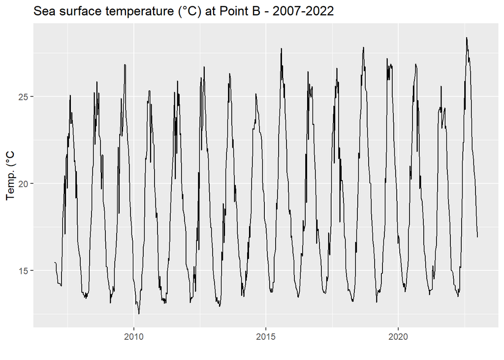

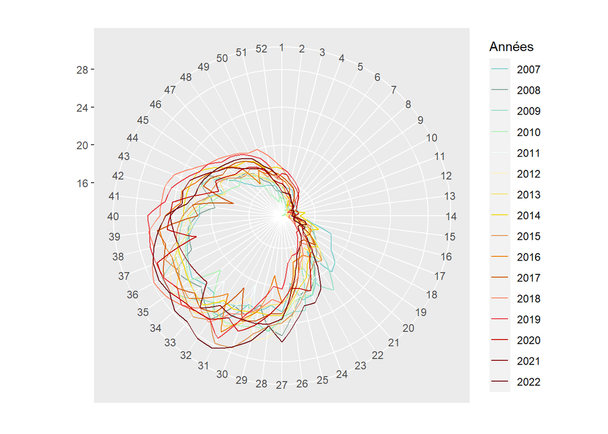

*Correlogram*

Trend pattern (correlogram 1 : less correlation with increasing lags),  
Seasonal pattern (correlogram 2 : correlation (highest value at lag 52/53) and anti-correlation (lowest value at lag 26/27) successions),  
Periodicity = 52 (highest correlation value at 52/53)

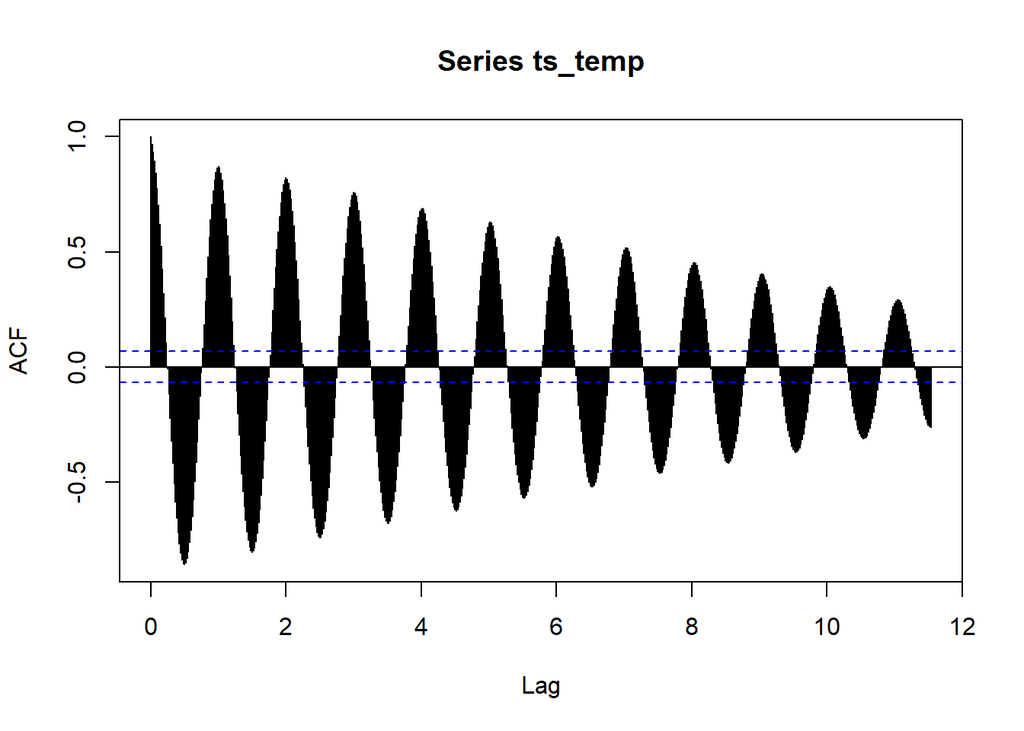

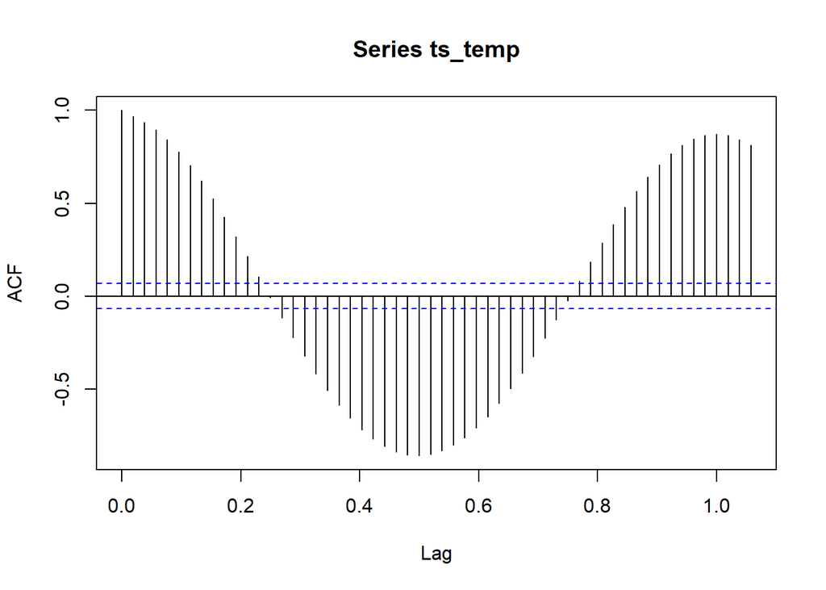

*Trend and seasonal patterns identification :*

Time series = Tt + St + ɛt  
with Tt : trend St : seasonal pattern ɛt : residual part

#### Trend estimation by moving average (manually) :

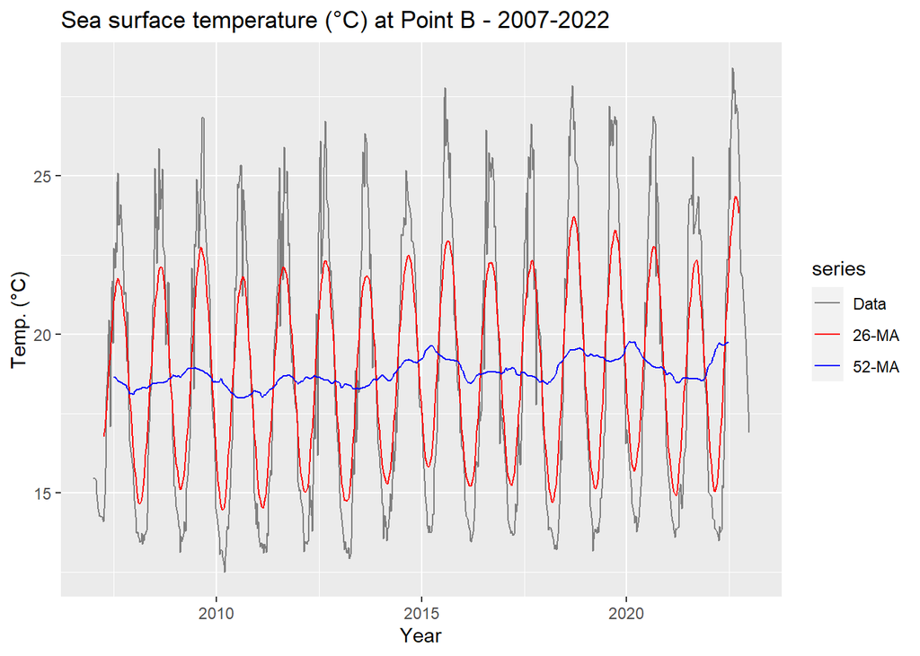

#### Trend estimation by moving average (decompose function) :

*Quick overview of the components of the series*  
*increasing trend more visible*

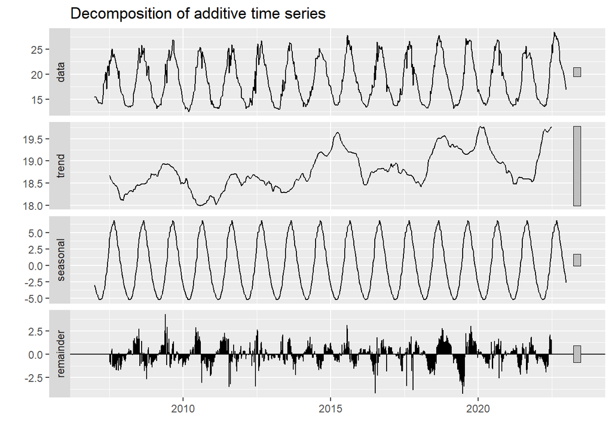

#### Remove seasonality :

→ measured values - seasonal pattern  
OR  
→ trend + remainders

*by appling trend on this series, we see the increase*

slope : 0.058 ± 0.009  
Int. : -98.07 ± 18.57

```
##
## Call:
## lm(formula = y ~ x, data = reg_val_less_season)
##
## Residuals:
##     Min      1Q  Median      3Q     Max
## -4.3589 -0.7228 -0.1046  0.7712  4.6640
##
## Coefficients:
##               Estimate Std. Error t value Pr(>|t|)
## (Intercept) -98.074067  18.572196  -5.281 1.64e-07 ***
## x             0.058022   0.009217   6.295 4.97e-10 ***
## ---
## Signif. codes:  0 '***' 0.001 '**' 0.01 '*' 0.05 '.' 0.1 ' ' 1
##
## Residual standard error: 1.228 on 830 degrees of freedom
## Multiple R-squared:  0.04557,    Adjusted R-squared:  0.04442
## F-statistic: 39.63 on 1 and 830 DF,  p-value: 4.971e-10
```

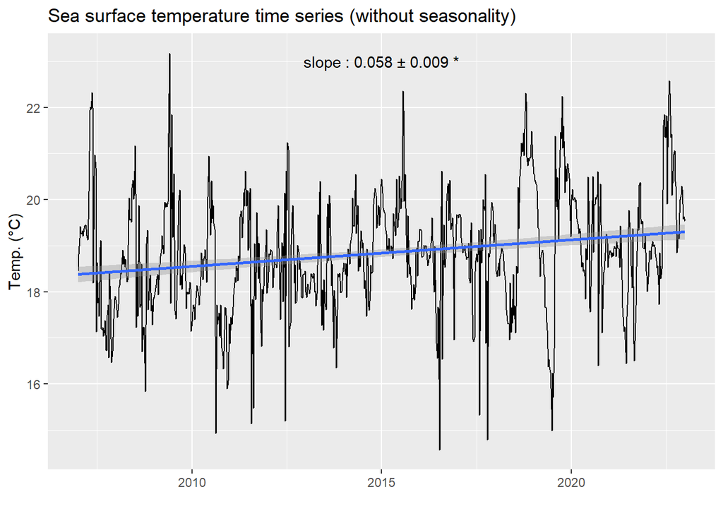

```
##          tau        slope    intercept
##   0.15799741   0.04960769 -65.78843542
```

#### White noise test :

If residuals of the time series are assimilated to a white noise = stationary time series  
Stationary time series = no trend + no seasonality

```
##
##  Box-Ljung test
##
## data:  ts_temp_decomp$random
## X-squared = 356.08, df = 1, p-value < 2.2e-16
```

*significative p-value, so we reject that residuals could be associated to a white noise*

#### WLS fit (Sutton et al. 2022) :

```
##
## Call:
## lm(formula = y ~ x, data = reg_val_less_season)
##
## Residuals:
##     Min      1Q  Median      3Q     Max
## -4.3589 -0.7228 -0.1046  0.7712  4.6640
##
## Coefficients:
##               Estimate Std. Error t value Pr(>|t|)
## (Intercept) -98.074067  18.572196  -5.281 1.64e-07 ***
## x             0.058022   0.009217   6.295 4.97e-10 ***
## ---
## Signif. codes:  0 '***' 0.001 '**' 0.01 '*' 0.05 '.' 0.1 ' ' 1
##
## Residual standard error: 1.228 on 830 degrees of freedom
## Multiple R-squared:  0.04557,    Adjusted R-squared:  0.04442
## F-statistic: 39.63 on 1 and 830 DF,  p-value: 4.971e-10
```

```
##
## Call:
## lm(formula = reg_val_less_season$y ~ reg_val_less_season$x, data = reg_val_less_season,
##     weights = weight)
##
## Weighted Residuals:
##     Min      1Q  Median      3Q     Max
## -4.6580 -0.7725 -0.1122  0.8246  5.0327
##
## Coefficients:
##                         Estimate Std. Error t value Pr(>|t|)
## (Intercept)           -97.539344  18.569373  -5.253 1.91e-07 ***
## reg_val_less_season$x   0.057757   0.009216   6.267 5.90e-10 ***
## ---
## Signif. codes:  0 '***' 0.001 '**' 0.01 '*' 0.05 '.' 0.1 ' ' 1
##
## Residual standard error: 1.315 on 830 degrees of freedom
## Multiple R-squared:  0.04518,    Adjusted R-squared:  0.04403
## F-statistic: 39.28 on 1 and 830 DF,  p-value: 5.904e-10
```

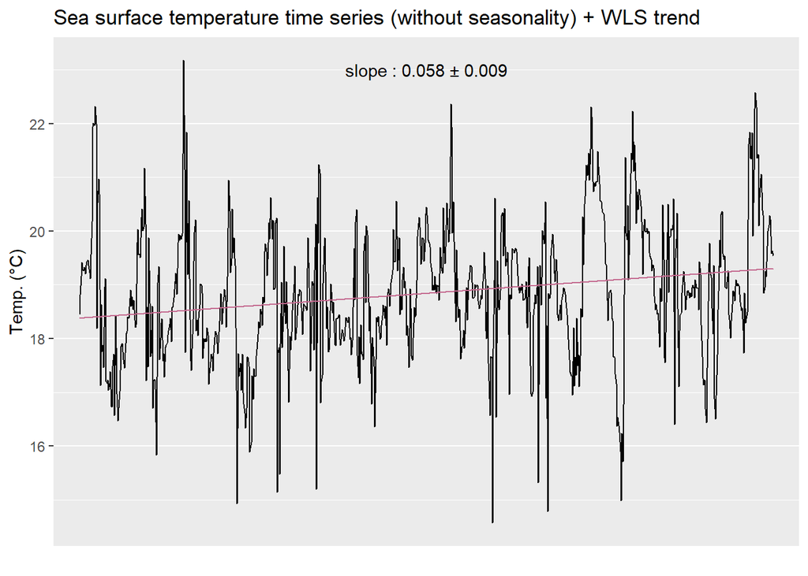

#### By residuals (Bates et al. 2014)

```
##                 Slope  SE Slope      P Slope Intercept  SE int.       P int.
## bio_pco2_ano 3.579404 0.1480491 8.166814e-97 -7210.629 298.2422 8.173096e-97
##                     F  df        R2      P value
## bio_pco2_ano 584.5344 780 0.4283764 8.166814e-97
```

```
##           tau         slope     intercept
##     0.5137064     3.4383908 -6856.7613994
```

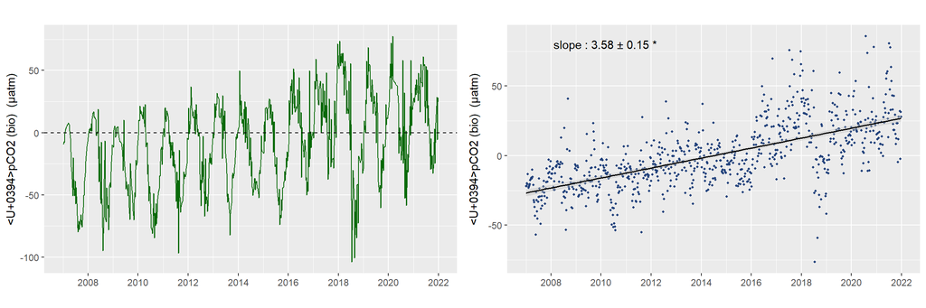

#### By autocorrelation (decompose function)

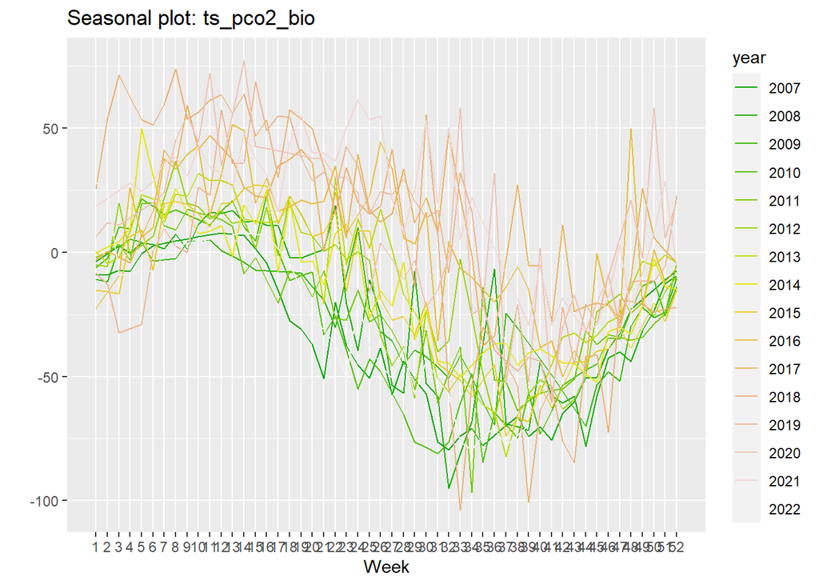

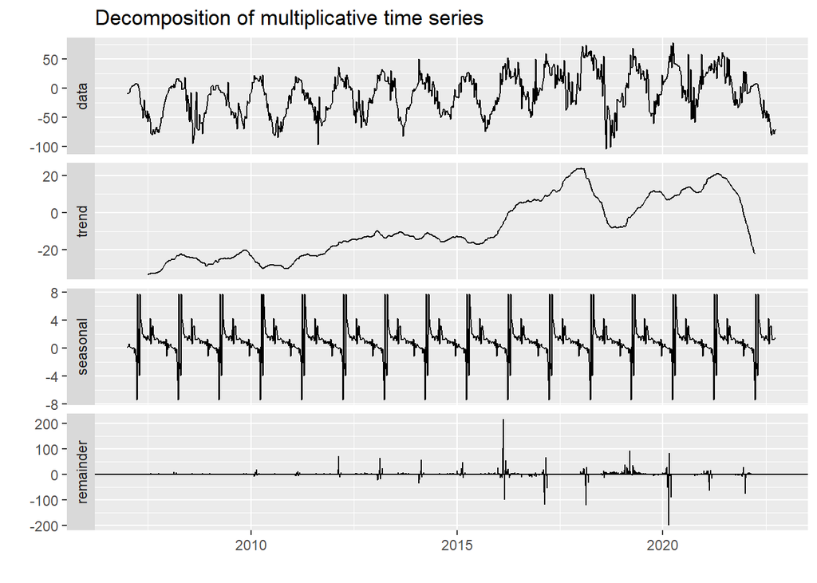

→ remove seasonality :

```
##
## Call:
## lm(formula = y ~ x, data = reg_val_ts_pco2_bio_less_season)
##
## Residuals:
##      Min       1Q   Median       3Q      Max
## -105.781  -25.057    2.733   26.832   76.232
##
## Coefficients:
##               Estimate Std. Error t value Pr(>|t|)
## (Intercept) -5038.9726   513.9073  -9.805   <2e-16 ***
## x               2.4957     0.2551   9.785   <2e-16 ***
## ---
## Signif. codes:  0 '***' 0.001 '**' 0.01 '*' 0.05 '.' 0.1 ' ' 1
##
## Residual standard error: 33.19 on 817 degrees of freedom
## Multiple R-squared:  0.1049, Adjusted R-squared:  0.1038
## F-statistic: 95.74 on 1 and 817 DF,  p-value: < 2.2e-16
```

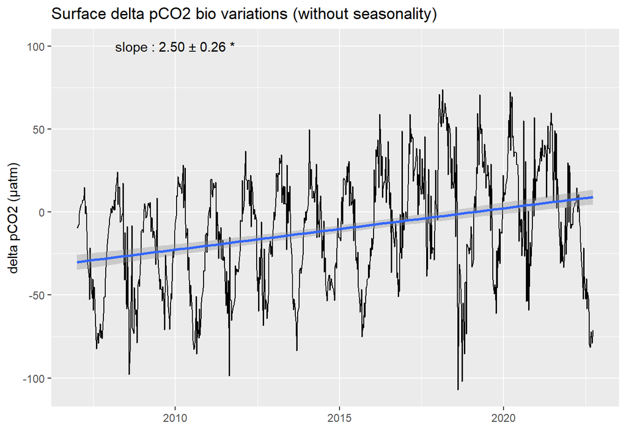

[output not shown]

## CO2 fluxes : Point B (2009-2021)

#### By residuals (Bates et al. 2014)

```
##                     Slope     SE Slope      P Slope    Intercept     SE int.
## flux_W92_ano 4.745219e-06 1.087736e-06 1.489053e-05 -0.009564072 0.002192355
## flux_W14_ano 4.814507e-06 1.167391e-06 4.189495e-05 -0.009703724 0.002352901
##                    P int.        F  df         R2      P value
## flux_W92_ano 1.489102e-05 19.03116 669 0.02766032 1.489053e-05
## flux_W14_ano 4.189620e-05 17.00869 669 0.02479369 4.189495e-05
```

```
##           tau         slope     intercept
##  1.535603e-01  1.805370e-06 -3.371450e-03
```

*by Wanninkhof et al. (2014) method :*  
Increase of CO2 fluxes (more and more sources)

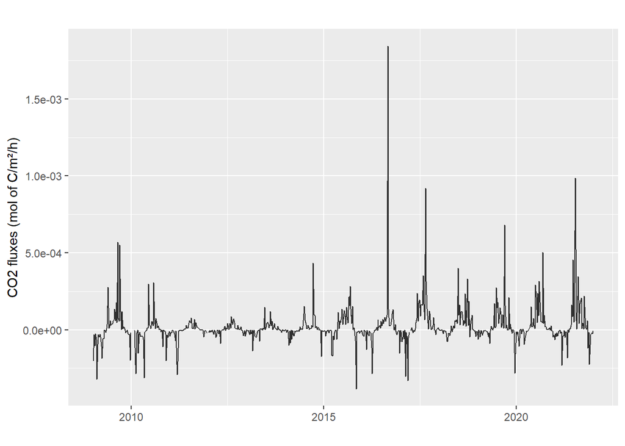

[figure not shown]

#### By autocorrelation (decompose function)

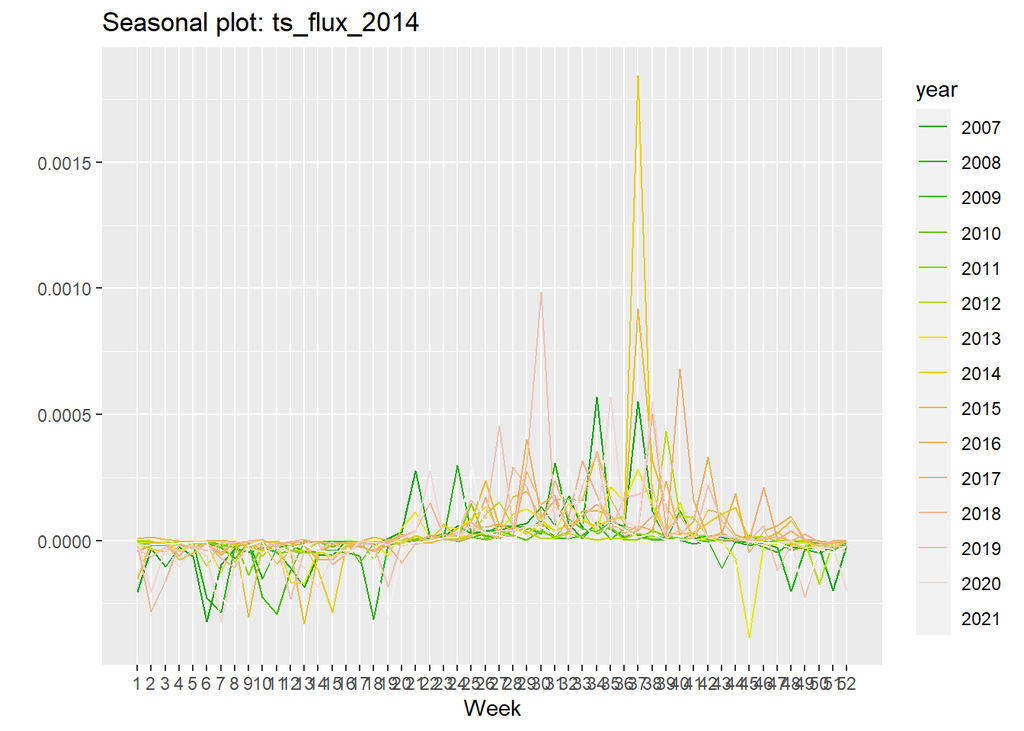

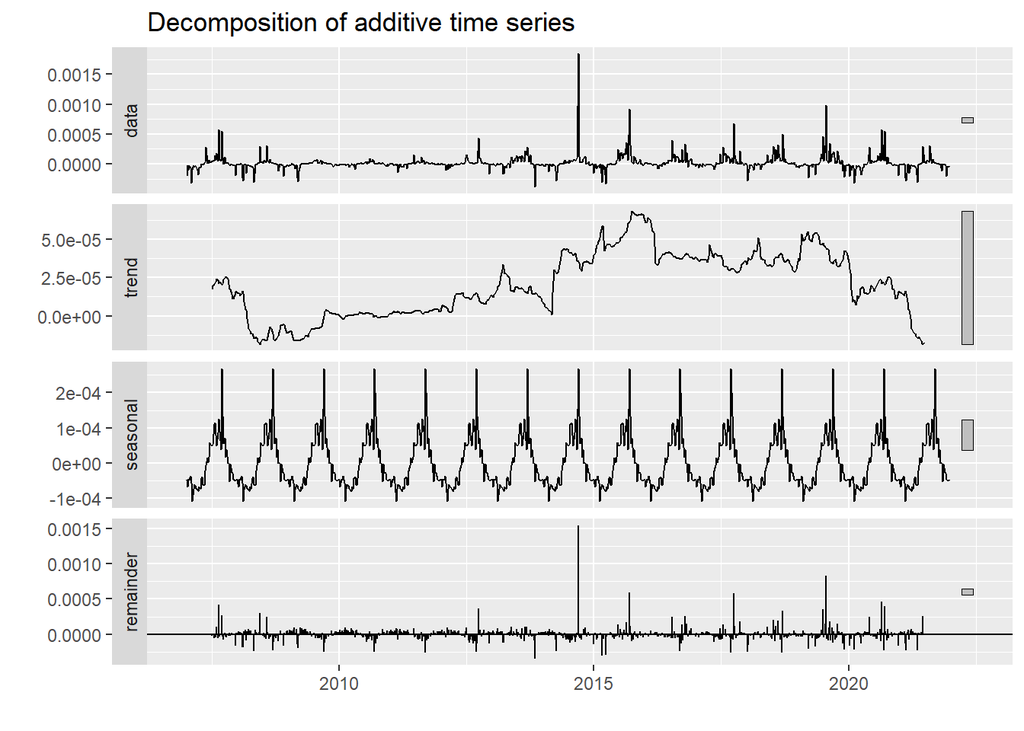

→ remove seasonality : bug dans les data

```
##
## Call:
## lm(formula = y ~ x, data = reg_val_ts_flux_2014_less_season)
##
## Residuals:
##        Min         1Q     Median         3Q        Max
## -3.488e-04 -3.568e-05  7.000e-07  3.192e-05  1.557e-03
##
## Coefficients:
##               Estimate Std. Error t value Pr(>|t|)
## (Intercept) -4.034e-03  1.814e-03  -2.223   0.0265 *
## x            2.012e-06  9.006e-07   2.234   0.0258 *
## ---
## Signif. codes:  0 '***' 0.001 '**' 0.01 '*' 0.05 '.' 0.1 ' ' 1
##
## Residual standard error: 0.0001089 on 778 degrees of freedom
## Multiple R-squared:  0.006372,   Adjusted R-squared:  0.005095
## F-statistic: 4.989 on 1 and 778 DF,  p-value: 0.02579
```

[output not shown]

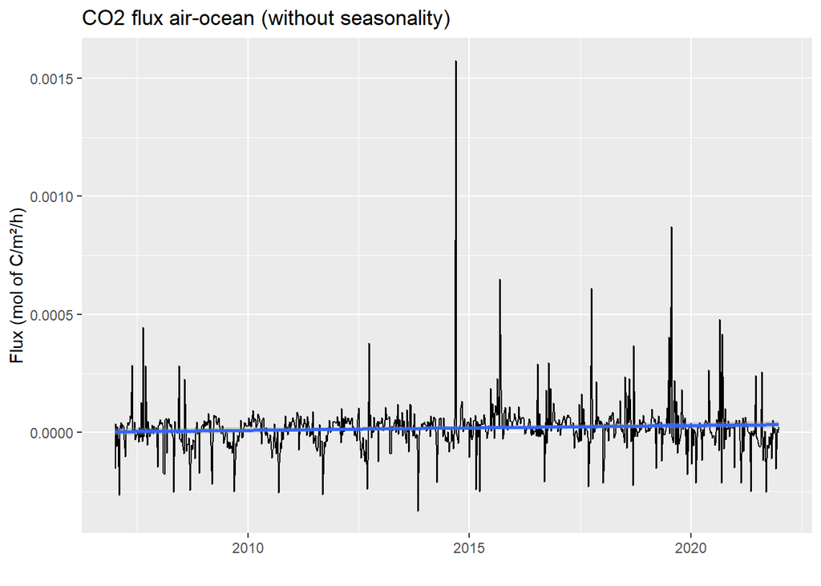

## Point B - period 2007-2022

### SURFACE

- Temperature (°C) → done above ✓
- Salinity
- pH calculated
- pH normalized (18 °C)
- Total alcalinity (µmol/kg)
- Total carbon - DIC (µmol/kg)
- Seawater pCO<sub>2</sub> (µatm)

#### By autocorrelation (decompose function)

###### Salinity :

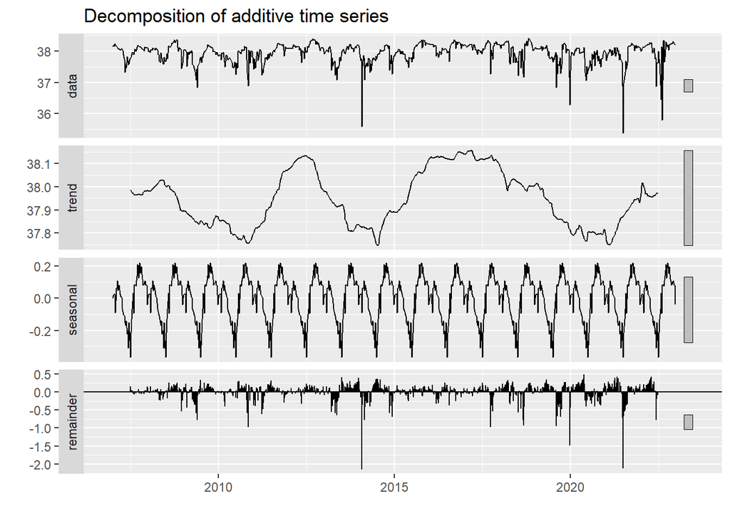

```
##
## Call:
## lm(formula = y ~ x, data = reg_val_ts_sal_less_season)
##
## Residuals:
##      Min       1Q   Median       3Q      Max
## -2.26888 -0.07384  0.05299  0.16776  0.43462
##
## Coefficients:
##               Estimate Std. Error t value Pr(>|t|)
## (Intercept)  3.815e+01  4.277e+00   8.918   <2e-16 ***
## x           -9.817e-05  2.123e-03  -0.046    0.963
## ---
## Signif. codes:  0 '***' 0.001 '**' 0.01 '*' 0.05 '.' 0.1 ' ' 1
##
## Residual standard error: 0.2828 on 830 degrees of freedom
## Multiple R-squared:  2.577e-06,  Adjusted R-squared:  -0.001202
## F-statistic: 0.002139 on 1 and 830 DF,  p-value: 0.9631
```

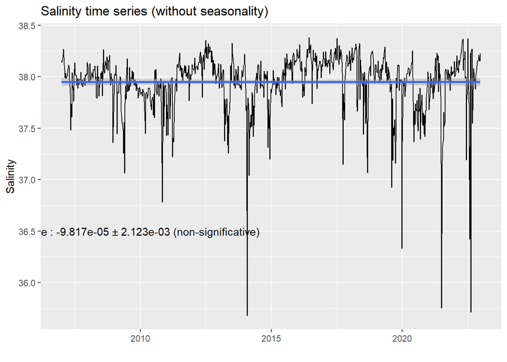

```
##         tau       slope   intercept
##  0.08353456  0.00490000 28.60030667
```

###### pH calculated :

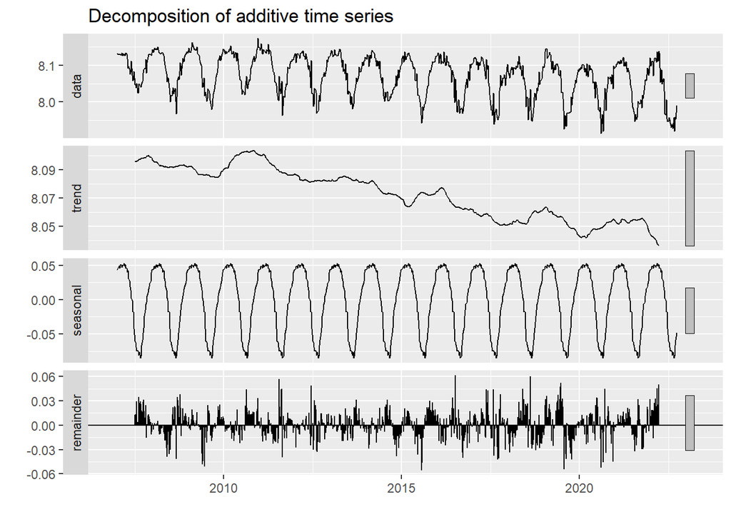

```
##
## Call:
## lm(formula = y ~ x, data = reg_val_ts_pH_less_season)
##
## Residuals:
##       Min        1Q    Median        3Q       Max
## -0.076080 -0.012476  0.000513  0.011960  0.060379
##
## Coefficients:
##               Estimate Std. Error t value Pr(>|t|)
## (Intercept) 16.0024176  0.3081464   51.93   <2e-16 ***
## x           -0.0039360  0.0001529  -25.74   <2e-16 ***
## ---
## Signif. codes:  0 '***' 0.001 '**' 0.01 '*' 0.05 '.' 0.1 ' ' 1
##
## Residual standard error: 0.0199 on 817 degrees of freedom
## Multiple R-squared:  0.4477, Adjusted R-squared:  0.4471
## F-statistic: 662.3 on 1 and 817 DF,  p-value: < 2.2e-16
```

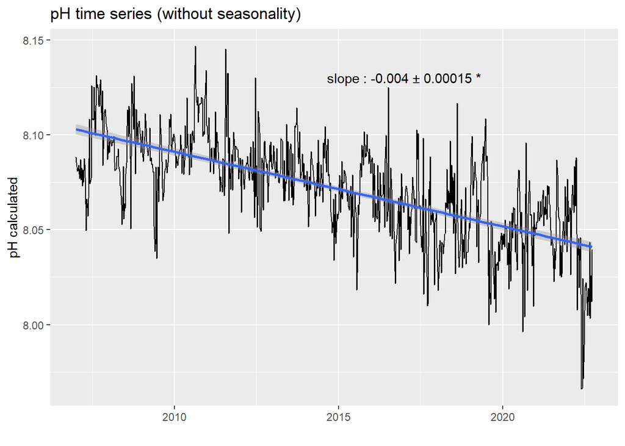

```
##          tau        slope    intercept
## -0.507330174 -0.003704364 14.971413986
```

###### pH normalized (18) :

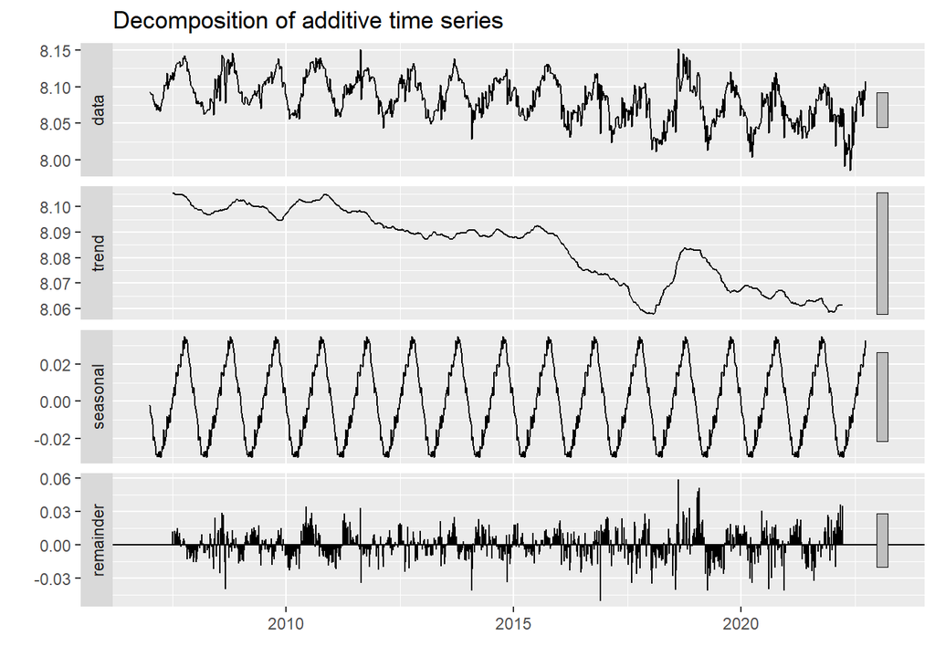

```
##
## Call:
## lm(formula = y ~ x, data = reg_val_ts_pH_18_less_season)
##
## Residuals:
##       Min        1Q    Median        3Q       Max
## -0.060691 -0.009506  0.000687  0.009573  0.065294
##
## Coefficients:
##               Estimate Std. Error t value Pr(>|t|)
## (Intercept) 14.3268199  0.2375706   60.31   <2e-16 ***
## x           -0.0030983  0.0001179  -26.28   <2e-16 ***
## ---
## Signif. codes:  0 '***' 0.001 '**' 0.01 '*' 0.05 '.' 0.1 ' ' 1
##
## Residual standard error: 0.01534 on 817 degrees of freedom
## Multiple R-squared:  0.458,  Adjusted R-squared:  0.4574
## F-statistic: 690.5 on 1 and 817 DF,  p-value: < 2.2e-16
```

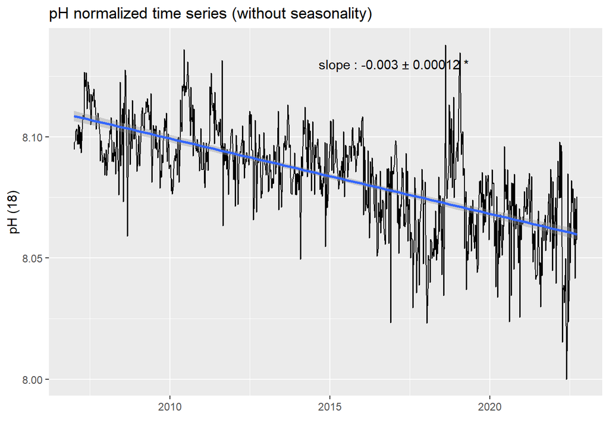

```
##          tau        slope    intercept
## -0.518178316 -0.003066204 14.369182200
```

###### Total alcalinity :

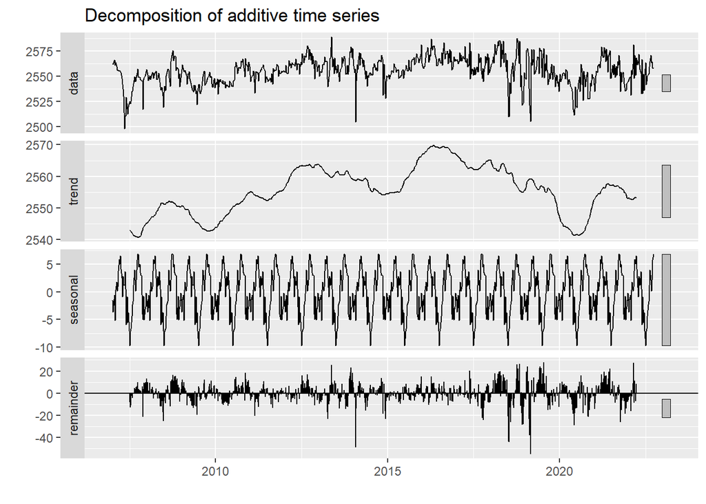

```
##
## Call:
## lm(formula = y ~ x, data = reg_val_ts_ta_less_season)
##
## Residuals:
##     Min      1Q  Median      3Q     Max
## -54.183  -7.254   0.808   8.163  30.760
##
## Coefficients:
##              Estimate Std. Error t value Pr(>|t|)
## (Intercept) 1.429e+03  1.945e+02   7.351 4.80e-13 ***
## x           5.588e-01  9.651e-02   5.790 1.01e-08 ***
## ---
## Signif. codes:  0 '***' 0.001 '**' 0.01 '*' 0.05 '.' 0.1 ' ' 1
##
## Residual standard error: 12.56 on 817 degrees of freedom
## Multiple R-squared:  0.03941,    Adjusted R-squared:  0.03824
## F-statistic: 33.52 on 1 and 817 DF,  p-value: 1.006e-08
```

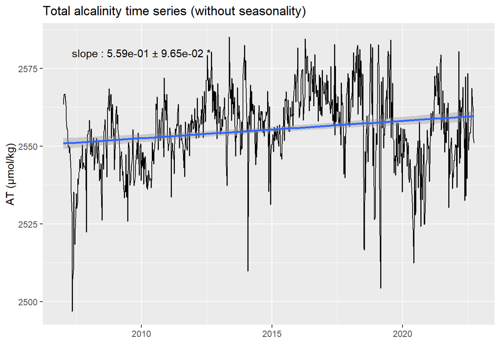

```
##         tau       slope   intercept
##   0.1524274   0.6902784 997.1132050
```

###### Total carbon :

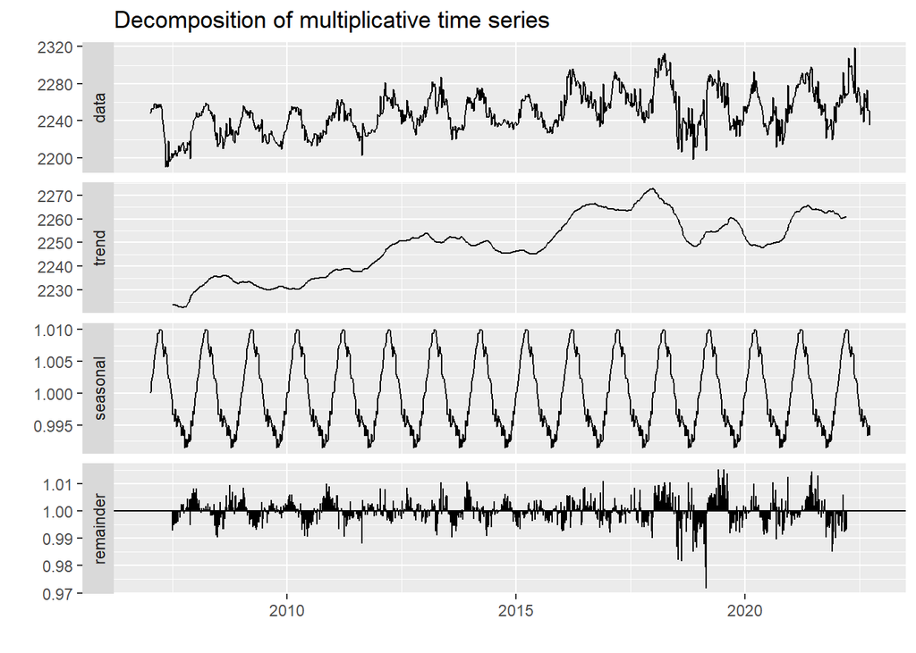

```
##
## Call:
## lm(formula = y ~ x, data = reg_val_ts_dic_less_season)
##
## Residuals:
##    Min     1Q Median     3Q    Max
## -60.17 -14.03  -0.83  14.51  55.79
##
## Coefficients:
##               Estimate Std. Error t value Pr(>|t|)
## (Intercept) -2521.6374   302.5181  -8.335 3.25e-16 ***
## x               2.3672     0.1501  15.766  < 2e-16 ***
## ---
## Signif. codes:  0 '***' 0.001 '**' 0.01 '*' 0.05 '.' 0.1 ' ' 1
##
## Residual standard error: 19.54 on 817 degrees of freedom
## Multiple R-squared:  0.2333, Adjusted R-squared:  0.2323
## F-statistic: 248.6 on 1 and 817 DF,  p-value: < 2.2e-16
```

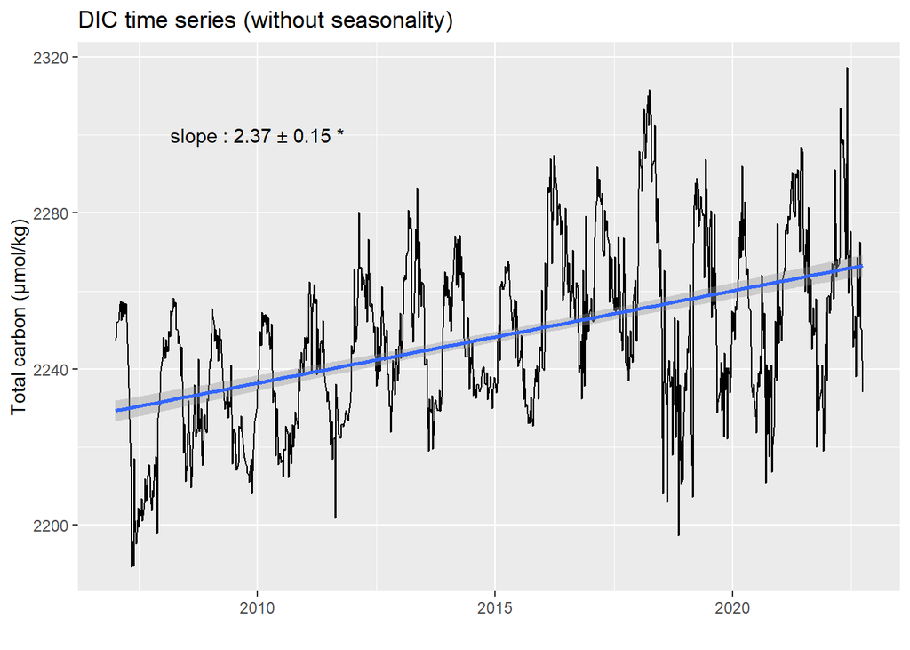

```
##           tau         slope     intercept
##     0.4775709     2.4504033 -2706.5094691
```

###### Seawater pCO<sub>2</sub>

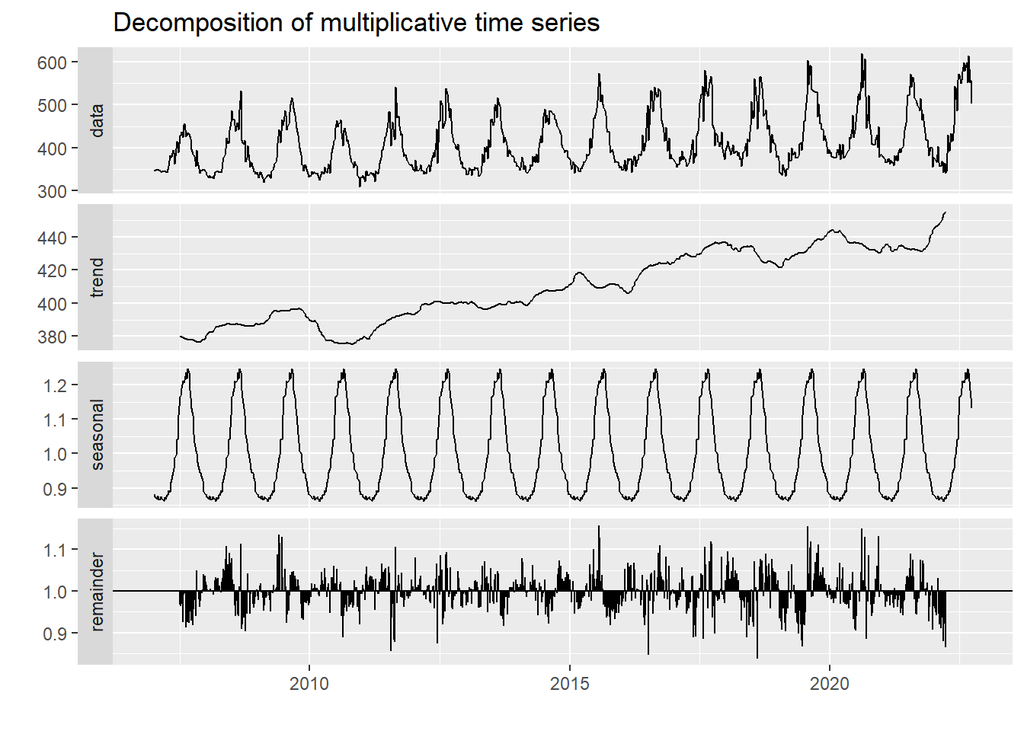

```
##
## Call:
## lm(formula = y ~ x, data = reg_val_ts_pco2w_less_season)
##
## Residuals:
##     Min      1Q  Median      3Q     Max
## -107.13  -46.92  -22.05   44.40  177.38
##
## Coefficients:
##               Estimate Std. Error t value Pr(>|t|)
## (Intercept) -1.003e+04  9.222e+02  -10.88   <2e-16 ***
## x            5.181e+00  4.577e-01   11.32   <2e-16 ***
## ---
## Signif. codes:  0 '***' 0.001 '**' 0.01 '*' 0.05 '.' 0.1 ' ' 1
##
## Residual standard error: 59.55 on 817 degrees of freedom
## Multiple R-squared:  0.1356, Adjusted R-squared:  0.1345
## F-statistic: 128.1 on 1 and 817 DF,  p-value: < 2.2e-16
```

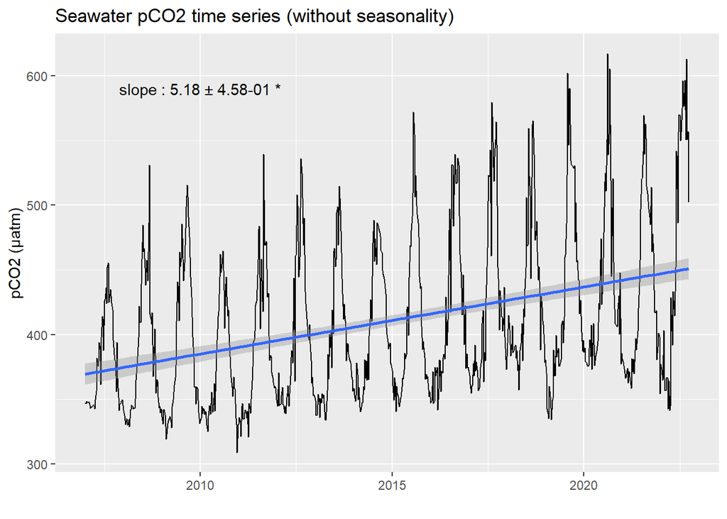

```
##           tau         slope     intercept
##     0.5200348     4.1251714 -7419.0790765
```

### 50 m

- Temperature (°C)
- Salinity
- pH calculated
- pH normalized (18 °C)
- Total alcalinity (µmol/kg)
- Total carbon - DIC (µmol/kg)
- Seawater pCO<sub>2</sub> (µatm)

#### By autocorrelation (decompose function)

###### Temperature :

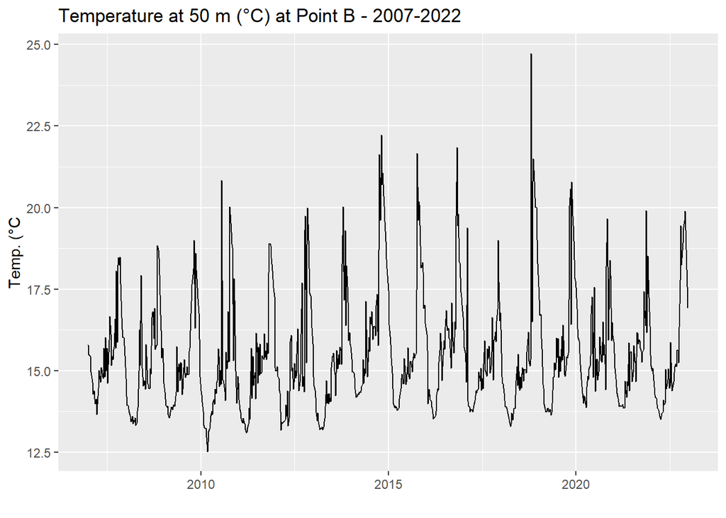

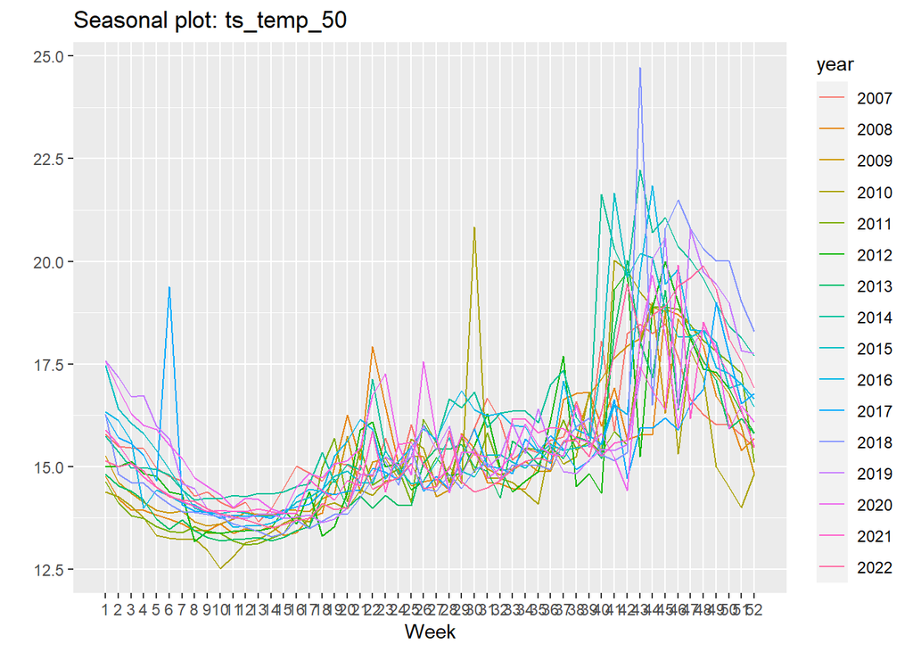

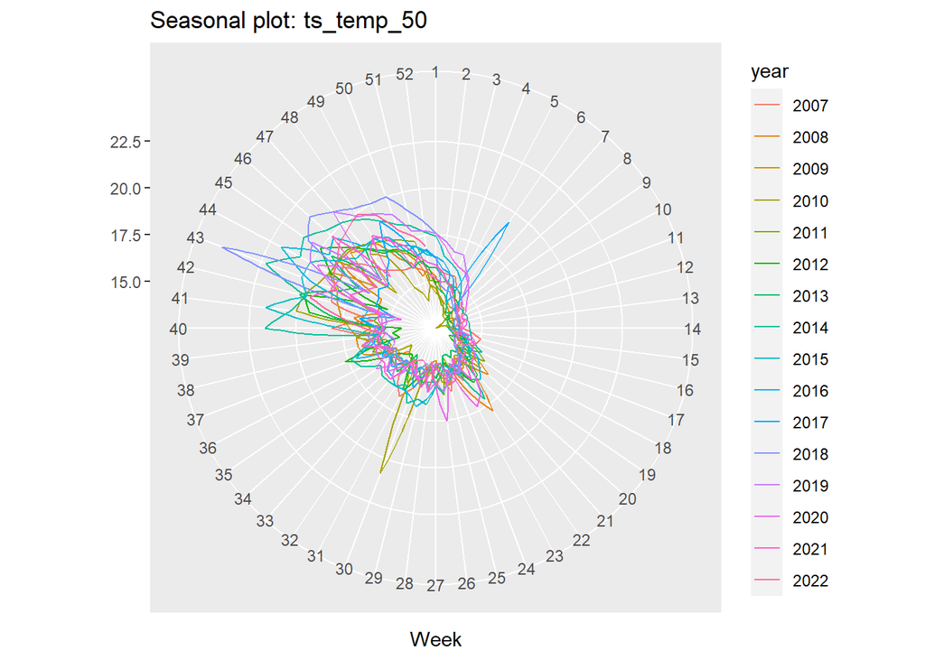

```
##         tau       slope   intercept
##   0.1110322   0.0243000 -37.2137708
```